# Bankovnidata_html

```python
import pandas as pd
import numpy as np
import seaborn as sns
from collections import Counter
import matplotlib.pyplot as plt
from sklearn.preprocessing import StandardScaler
from sklearn.linear_model import LogisticRegression
from sklearn.linear_model import LogisticRegressionCV
from sklearn.ensemble import RandomForestClassifier
from sklearn.metrics import classification_report, accuracy_score
from sklearn.model_selection import train_test_split
from sklearn.metrics import classification_report, confusion_matrix
from sklearn.model_selection import GridSearchCV
import matplotlib.pyplot as plt
from sklearn.tree import plot_tree
from sklearn.metrics import roc_curve, auc
import matplotlib
from sklearn.tree import DecisionTreeClassifier
from sklearn.metrics import confusion_matrix, ConfusionMatrixDisplay
from sklearn.tree import DecisionTreeClassifier
from imblearn.over_sampling import RandomOverSampler, SMOTE
from imblearn.under_sampling import RandomUnderSampler
```

## Popis datasetu

Využívaná data se týkají přímých marketingových kampaní portugalské banky (Portuguese banking institution). Marketingové kampaně byly realizovány přes telefonní hovory. V několika případech bylo nutné uskutečnit kontakt s klientem vícekrát, pro zjistění, zda došlo k otevření a často bylo třeba provést více než jeden kontakt se stejným klientem, aby bylo možné zjistit, zda byl termínovaný vklad sjednán.

Zdroj: https://archive.ics.uci.edu/ml/datasets/bank+marketing

```python
# Načtění csv souboru do pandas DataFrame a výpis prvních 10 řádků

df = pd.read_csv('./data/bank-additional-full.csv', sep=";")

df.head(10)
```

|  | age | job | marital | education | default | housing | loan | contact | month | day_of_week | ... | campaign | pdays | previous | poutcome | emp.var.rate | cons.price.idx | cons.conf.idx | euribor3m | nr.employed | y |
| --- | --- | --- | --- | --- | --- | --- | --- | --- | --- | --- | --- | --- | --- | --- | --- | --- | --- | --- | --- | --- | --- |
| 0 | 56 | housemaid | married | basic.4y | no | no | no | telephone | may | mon | ... | 1 | 999 | 0 | nonexistent | 1.1 | 93.994 | -36.4 | 4.857 | 5191.0 | no |
| 1 | 57 | services | married | high.school | unknown | no | no | telephone | may | mon | ... | 1 | 999 | 0 | nonexistent | 1.1 | 93.994 | -36.4 | 4.857 | 5191.0 | no |
| 2 | 37 | services | married | high.school | no | yes | no | telephone | may | mon | ... | 1 | 999 | 0 | nonexistent | 1.1 | 93.994 | -36.4 | 4.857 | 5191.0 | no |
| 3 | 40 | admin. | married | basic.6y | no | no | no | telephone | may | mon | ... | 1 | 999 | 0 | nonexistent | 1.1 | 93.994 | -36.4 | 4.857 | 5191.0 | no |
| 4 | 56 | services | married | high.school | no | no | yes | telephone | may | mon | ... | 1 | 999 | 0 | nonexistent | 1.1 | 93.994 | -36.4 | 4.857 | 5191.0 | no |
| 5 | 45 | services | married | basic.9y | unknown | no | no | telephone | may | mon | ... | 1 | 999 | 0 | nonexistent | 1.1 | 93.994 | -36.4 | 4.857 | 5191.0 | no |
| 6 | 59 | admin. | married | professional.course | no | no | no | telephone | may | mon | ... | 1 | 999 | 0 | nonexistent | 1.1 | 93.994 | -36.4 | 4.857 | 5191.0 | no |
| 7 | 41 | blue-collar | married | unknown | unknown | no | no | telephone | may | mon | ... | 1 | 999 | 0 | nonexistent | 1.1 | 93.994 | -36.4 | 4.857 | 5191.0 | no |
| 8 | 24 | technician | single | professional.course | no | yes | no | telephone | may | mon | ... | 1 | 999 | 0 | nonexistent | 1.1 | 93.994 | -36.4 | 4.857 | 5191.0 | no |
| 9 | 25 | services | single | high.school | no | yes | no | telephone | may | mon | ... | 1 | 999 | 0 | nonexistent | 1.1 | 93.994 | -36.4 | 4.857 | 5191.0 | no |

10 rows × 21 columns

```python
# Zobrazení počtu řádků a sloupců
print("Rows count: ", df.shape[0])
print("Columns count: ", df.shape[1])
```

```
Rows count:  41188
Columns count:  21
```

Datový soubor obsahuje 20 proměnných,

- 10 numerických
- 10 kategorických a jednu cílovou proměnnou "y", která určuje, zda klient sjednal termínovaný vklad a dosahuje hodnoty "yes" (termínovaný vklad sjednán) a "no" (termínovaný vklad nebyl sjednán).

Soubor obsahuje 41188 pozorování.

Kategorické proměnné

- 11 - Job: Typ zaměstnání klienta (např. zaměstnanec, důchodce, podnikatel atd.).
- 12 - Marital: Rodinný stav klienta (např. svobodný, ženatý, rozvedený).
- 13 - Education: Vzdělání klienta (např. základní, střední, vysokoškolské).
- 14 - Default: Zda má klient úvěrové selhání (ano/ne).
- 15 - Housing: Zda má klient hypotéku (ano/ne).
- 16 - Loan: Zda má klient osobní půjčku (ano/ne).
- 17 - Contact: Způsob kontaktu (např. mobilní, pevná linka).
- 18 - Month: Měsíc posledního kontaktu (např. leden, únor atd.).
- 19 - Weekday: Den v týdnu posledního kontaktu (např. pondělí, úterý).
- 20 - Poutcome: Výsledek předchozí marketingové kampaně (např. úspěšná, neúspěšná, žádná).

Cílová proměnná Subscription: Binární proměnná indikující, zda klient podepsal termínovaný vklad (ano/ne).

## PŘEDZPRACOVÁNÍ DAT

```python
# Získání souhrnných statistik pro data
df.describe
```

```
<bound method NDFrame.describe of        age          job  marital            education  default housing loan  \
0       56    housemaid  married             basic.4y       no      no   no
1       57     services  married          high.school  unknown      no   no
2       37     services  married          high.school       no     yes   no
3       40       admin.  married             basic.6y       no      no   no
4       56     services  married          high.school       no      no  yes
...    ...          ...      ...                  ...      ...     ...  ...
41183   73      retired  married  professional.course       no     yes   no
41184   46  blue-collar  married  professional.course       no      no   no
41185   56      retired  married    university.degree       no     yes   no
41186   44   technician  married  professional.course       no      no   no
41187   74      retired  married  professional.course       no     yes   no

         contact month day_of_week  ...  campaign  pdays  previous  \
0      telephone   may         mon  ...         1    999         0
```

[output cut: 38 more lines]

```python
df.info()
# Zde vidíme, kolik hodnot a jakého typu proměnná je
```

```
<class 'pandas.core.frame.DataFrame'>
RangeIndex: 41188 entries, 0 to 41187
Data columns (total 21 columns):
 #   Column          Non-Null Count  Dtype
---  ------          --------------  -----
 0   age             41188 non-null  int64
 1   job             41188 non-null  object
 2   marital         41188 non-null  object
 3   education       41188 non-null  object
 4   default         41188 non-null  object
 5   housing         41188 non-null  object
 6   loan            41188 non-null  object
 7   contact         41188 non-null  object
 8   month           41188 non-null  object
 9   day_of_week     41188 non-null  object
 10  duration        41188 non-null  int64
 11  campaign        41188 non-null  int64
 12  pdays           41188 non-null  int64
 13  previous        41188 non-null  int64
 14  poutcome        41188 non-null  object
 15  emp.var.rate    41188 non-null  float64
 16  cons.price.idx  41188 non-null  float64
 17  cons.conf.idx   41188 non-null  float64
 18  euribor3m       41188 non-null  float64
 19  nr.employed     41188 non-null  float64
 20  y               41188 non-null  object
dtypes: float64(5), int64(5), object(11)
memory usage: 6.6+ MB
```

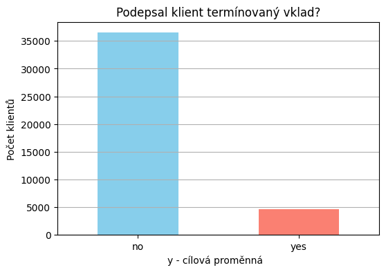

```python
# Vizualizace cílové proměnné
plt.figure(figsize=(6, 4))
df['y'].value_counts().plot(kind='bar', color=['skyblue', 'salmon'])
plt.title('Podepsal klient termínovaný vklad?')
plt.xlabel('y - cílová proměnná  ')
plt.ylabel('Počet klientů')
plt.xticks(rotation=0)
plt.grid(axis='y')

# Zobrazení histogramu
plt.show()
```

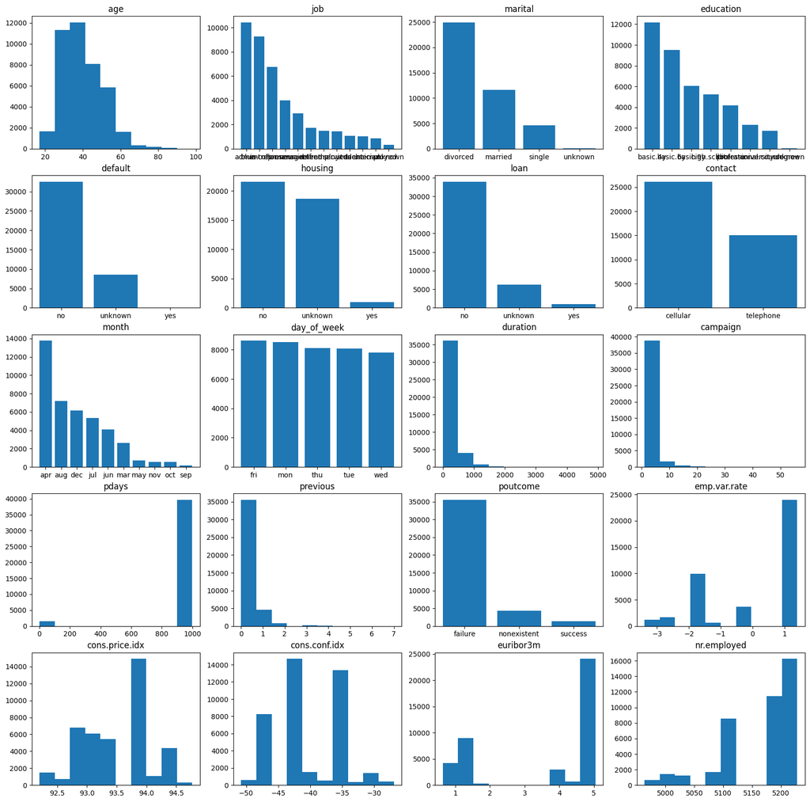

```python
# Vizualizace vstupujících proměnných
fig = plt.figure(figsize=(20,20))
cols = list(df.columns)
cols.remove("y")

for i, name in enumerate(cols):
    x = fig.add_subplot(5,4,i+1)
    if (df[name].dtype=="object"):
        x.bar(df[name].sort_values().unique(), df[name].value_counts())
    else:
        x.hist(df[name])
    x.set_title(name)
```

```python
# Ošetření chybějících hodnot - je nutné nahradit hodnoty "unknown" hodnotami NA

df2=df.replace(to_replace="unknown",value=pd.NA)
df2["pdays"]=df2[["pdays"]].replace(to_replace=999,value=np.nan)
df2.head()
```

|  | age | job | marital | education | default | housing | loan | contact | month | day_of_week | ... | campaign | pdays | previous | poutcome | emp.var.rate | cons.price.idx | cons.conf.idx | euribor3m | nr.employed | y |
| --- | --- | --- | --- | --- | --- | --- | --- | --- | --- | --- | --- | --- | --- | --- | --- | --- | --- | --- | --- | --- | --- |
| 0 | 56 | housemaid | married | basic.4y | no | no | no | telephone | may | mon | ... | 1 | NaN | 0 | nonexistent | 1.1 | 93.994 | -36.4 | 4.857 | 5191.0 | no |
| 1 | 57 | services | married | high.school | <NA> | no | no | telephone | may | mon | ... | 1 | NaN | 0 | nonexistent | 1.1 | 93.994 | -36.4 | 4.857 | 5191.0 | no |
| 2 | 37 | services | married | high.school | no | yes | no | telephone | may | mon | ... | 1 | NaN | 0 | nonexistent | 1.1 | 93.994 | -36.4 | 4.857 | 5191.0 | no |
| 3 | 40 | admin. | married | basic.6y | no | no | no | telephone | may | mon | ... | 1 | NaN | 0 | nonexistent | 1.1 | 93.994 | -36.4 | 4.857 | 5191.0 | no |
| 4 | 56 | services | married | high.school | no | no | yes | telephone | may | mon | ... | 1 | NaN | 0 | nonexistent | 1.1 | 93.994 | -36.4 | 4.857 | 5191.0 | no |

5 rows × 21 columns

```python
# Nyní můžeme zjistit pro každý sloupec chybějící hodnoty a jejich počet
na=df2.isnull()
na.sum()
```

```
age                   0
job                 330
marital              80
education          1731
default            8597
housing             990
loan                990
contact               0
month                 0
day_of_week           0
duration              0
campaign              0
pdays             39673
previous              0
poutcome              0
emp.var.rate          0
cons.price.idx        0
cons.conf.idx         0
euribor3m             0
nr.employed           0
y                     0
dtype: int64
```

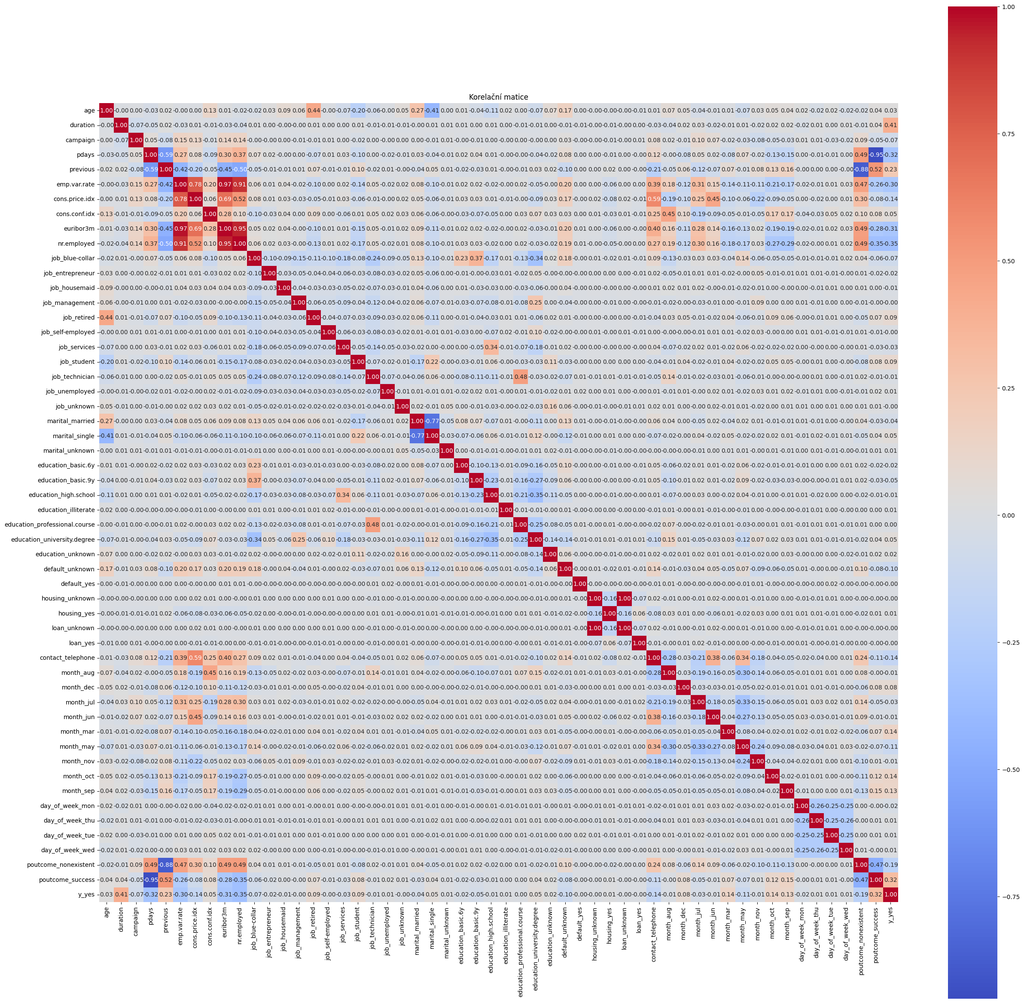

```python
# Korelace
df_encoded = pd.get_dummies(df, drop_first=True)

# Vytvoření korelační matice
correlation_matrix = df_encoded.corr()

# Vizualizace korelace mezi proměnnými v datasetu pomocí heatmapy
plt.figure(figsize=(30, 30))
sns.heatmap(correlation_matrix, annot=True, fmt=".2f", cmap='coolwarm', square=True)
plt.title('Korelační matice')
plt.show()
```

```python
# Rozdělení věku do intervalů
age_bins = [17, 29, 39, 49, 64, 98]
age_labels = ['17-29', '30-39', '40-49', '50-64', '65+']
df2['age_group'] = pd.cut(df['age'], bins=age_bins, labels=age_labels)
```

```python
# Odstranění nepotřebných sloupců
df2=df2.drop(["pdays", "duration", "nr.employed","poutcome","contact", "age"],axis=1)
df2.head(10) # Zobrazení dat pro kontrolu
```

|  | job | marital | education | default | housing | loan | month | day_of_week | campaign | previous | emp.var.rate | cons.price.idx | cons.conf.idx | euribor3m | y | age_group |
| --- | --- | --- | --- | --- | --- | --- | --- | --- | --- | --- | --- | --- | --- | --- | --- | --- |
| 0 | housemaid | married | basic.4y | no | no | no | may | mon | 1 | 0 | 1.1 | 93.994 | -36.4 | 4.857 | no | 50-64 |
| 1 | services | married | high.school | <NA> | no | no | may | mon | 1 | 0 | 1.1 | 93.994 | -36.4 | 4.857 | no | 50-64 |
| 2 | services | married | high.school | no | yes | no | may | mon | 1 | 0 | 1.1 | 93.994 | -36.4 | 4.857 | no | 30-39 |
| 3 | admin. | married | basic.6y | no | no | no | may | mon | 1 | 0 | 1.1 | 93.994 | -36.4 | 4.857 | no | 40-49 |
| 4 | services | married | high.school | no | no | yes | may | mon | 1 | 0 | 1.1 | 93.994 | -36.4 | 4.857 | no | 50-64 |
| 5 | services | married | basic.9y | <NA> | no | no | may | mon | 1 | 0 | 1.1 | 93.994 | -36.4 | 4.857 | no | 40-49 |
| 6 | admin. | married | professional.course | no | no | no | may | mon | 1 | 0 | 1.1 | 93.994 | -36.4 | 4.857 | no | 50-64 |
| 7 | blue-collar | married | <NA> | <NA> | no | no | may | mon | 1 | 0 | 1.1 | 93.994 | -36.4 | 4.857 | no | 40-49 |
| 8 | technician | single | professional.course | no | yes | no | may | mon | 1 | 0 | 1.1 | 93.994 | -36.4 | 4.857 | no | 17-29 |
| 9 | services | single | high.school | no | yes | no | may | mon | 1 | 0 | 1.1 | 93.994 | -36.4 | 4.857 | no | 17-29 |

Dataset neobsahuje také úplné informace o čase, pozorování jsou však sesbírána chronologicky. Vytvoříme novou proměnnou "year".

```python
# Vytvoření nové proměnné year
df2["year"] = 2008
add_year = 0
months = ["jan", "feb", "mar", "apr", "may", "jun", "jul", "aug", "sep", "oct", "nov", "dec"]
actual_month = df2.loc[0, "month"]

for i in df2.index:
    if (months.index(actual_month) > months.index(df2.loc[i, "month"])):
        add_year += 1
    df2.loc[i, "year"] += add_year
    actual_month = df2.loc[i, "month"]

print(df2.head())
```

```
         job  marital    education default housing loan month day_of_week  \
0  housemaid  married     basic.4y      no      no   no   may         mon
1   services  married  high.school    <NA>      no   no   may         mon
2   services  married  high.school      no     yes   no   may         mon
3     admin.  married     basic.6y      no      no   no   may         mon
4   services  married  high.school      no      no  yes   may         mon

   campaign  previous  emp.var.rate  cons.price.idx  cons.conf.idx  euribor3m  \
0         1         0           1.1          93.994          -36.4      4.857
1         1         0           1.1          93.994          -36.4      4.857
2         1         0           1.1          93.994          -36.4      4.857
3         1         0           1.1          93.994          -36.4      4.857
4         1         0           1.1          93.994          -36.4      4.857

    y age_group  year
0  no     50-64  2008
1  no     50-64  2008
2  no     30-39  2008
3  no     40-49  2008
4  no     50-64  2008
```

```
<bound method Figure.show of <Figure size 2000x1000 with 2 Axes>>
```

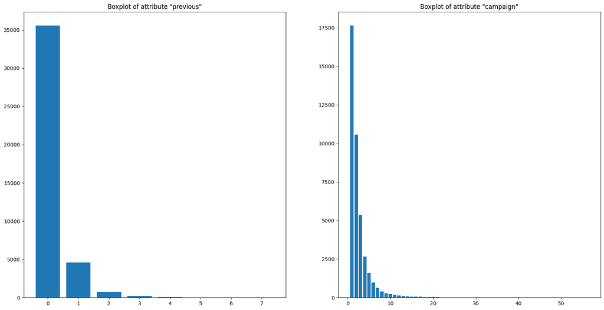

```python
# Vytvoření nových intervalů pro proměnné "previous" a "campaign"

fig = plt.figure(figsize=(20,10))
ax1 = fig.add_subplot(1, 2, 1)
ax2 = fig.add_subplot(1, 2, 2)

ax1.bar(df["previous"].sort_values().unique(), df["previous"].value_counts())
ax1.set_title('Boxplot of attribute "previous"')
ax2.bar(df["campaign"].sort_values().unique(), df["campaign"].value_counts())
ax2.set_title('Boxplot of attribute "campaign"')

fig.show
```

```python
df2["previous_cat"] = pd.cut(df2.previous, bins=[-1, 0, 2, 1000], labels=["0", "1-2", "3+"])
df2["campaign_cat"] = pd.cut(df2.campaign, bins=[-1, 0, 1, 2, 3, 4, 10, 1000], labels=["0", "1", "2", "3", "4", "5-10", "10+"])
#df2.head
# Zobrazení prvních několika řádků s novými kategoriemi
#print(df2[["previous", "previous_cat", "campaign", "campaign_cat"]].head())
```

```python
# Standardizace vybraných numerických sloupců
scaler = StandardScaler()

numeric_columns = ['emp.var.rate', 'cons.price.idx', 'cons.conf.idx', 'euribor3m']

df2[numeric_columns] = scaler.fit_transform(df2[numeric_columns])
```

```python
# Vytvoření kopie datasetu
df_cleaned = df2.copy()
print(df_cleaned.dtypes)
# Uložení vyčištěného datasetu do CSV souboru
df_cleaned.to_csv("data_cleaned.csv", index=False)
```

```
job                 object
marital             object
education           object
default             object
housing             object
loan                object
month               object
day_of_week         object
campaign             int64
previous             int64
emp.var.rate       float64
cons.price.idx     float64
cons.conf.idx      float64
euribor3m          float64
y                   object
age_group         category
year                 int64
previous_cat      category
campaign_cat      category
dtype: object
```

```python
# Oddělení atributů (features) a cílové proměnné (target)
X = df_cleaned.drop(columns=['y'])  # Všechny sloupce kromě 'y' - vstupní proměnné
y = df_cleaned['y'].values  # Cílová proměnná
```

```python
# Vytvoření proměnných feature_cols a odstranění cílové proměnné 'y', aby zůstaly pouze proměnné, které se budou používat jako vstupy do modelu
feature_cols = list(df_cleaned.columns)
feature_cols.remove("y")
```

```python
# Rozdělení dat na trénovací a testovací
X_train, X_test, y_train, y_test = train_test_split(X, y, test_size=0.2, random_state=42) # 20% testovací, 80% trénovací. Random state znamená, že při každém stuštění bude stejné rozložení dat

# Výpis velikosti trénovací a testovací sady
print("Počet záznamů v trénovací sadě:", X_train.shape[0])
print("Počet záznamů v testovací sadě:", X_test.shape[0])
```

```
Počet záznamů v trénovací sadě: 32950
Počet záznamů v testovací sadě: 8238
```

```python
# Řešení missing values - nahrazení NaN hodnot nejčastějšími hodnotami (mód)

for col in X_train.columns:
    if X_train[col].dtype == "object" or X_train[col].dtype == "category":
        mode_value = X_train[col].mode()[0]  # Získání módu
        X_train[col] = X_train[col].fillna(mode_value)



print(X_train)
na3=X_train.isnull()
na3.sum()
```

```
               job   marital            education default housing loan month  \
12556  blue-collar   married             basic.9y      no     yes   no   jul
35451       admin.   married    university.degree      no      no   no   may
30592      retired   married             basic.4y      no      no   no   may
17914    housemaid  divorced             basic.9y      no     yes   no   jul
3315        admin.    single          high.school      no      no   no   may
...            ...       ...                  ...     ...     ...  ...   ...
6265       retired   married  professional.course      no      no   no   may
11284   management   married    university.degree      no      no   no   jun
38158       admin.   married          high.school      no     yes   no   oct
860     management   married    university.degree      no     yes   no   may
15795       admin.    single    university.degree      no     yes   no   jul

      day_of_week  campaign  previous  emp.var.rate  cons.price.idx  \
12556         mon         2         0      0.839061        0.591424
```

[output cut: 25 more lines]

```
job               0
marital           0
education         0
default           0
housing           0
loan              0
month             0
day_of_week       0
campaign          0
previous          0
emp.var.rate      0
cons.price.idx    0
cons.conf.idx     0
euribor3m         0
age_group         0
year              0
previous_cat      0
campaign_cat      0
dtype: int64
```

```python
# Řešení missing values - nahrazení NaN hodnot nejčastějšími hodnotami (mód)

for col in X_test.columns:
    if X_test[col].dtype == "object" or X_test[col].dtype == "category":
        mode_value = X_test[col].mode()[0]  # Získání módu
        X_test[col] = X_test[col].fillna(mode_value)


print(X_test)

na4=X_test.isnull()
na4.sum()
```

```
                job   marital            education default housing loan month  \
32884    technician   married          high.school      no      no  yes   may
3169         admin.   married    university.degree      no     yes   no   may
32206   blue-collar   married             basic.9y      no      no   no   may
9403         admin.   married          high.school      no      no   no   jun
14020     housemaid   married          high.school      no     yes   no   jul
...             ...       ...                  ...     ...     ...  ...   ...
12322      services   married          high.school      no      no   no   jul
23440    technician  divorced  professional.course      no      no   no   aug
29431  entrepreneur    single    university.degree      no     yes  yes   apr
16627        admin.    single    university.degree      no     yes   no   jul
1871         admin.   married    university.degree      no     yes   no   may

      day_of_week  campaign  previous  emp.var.rate  cons.price.idx  \
32884         mon         1         1     -1.197935       -1.179380
```

[output cut: 25 more lines]

```
job               0
marital           0
education         0
default           0
housing           0
loan              0
month             0
day_of_week       0
campaign          0
previous          0
emp.var.rate      0
cons.price.idx    0
cons.conf.idx     0
euribor3m         0
age_group         0
year              0
previous_cat      0
campaign_cat      0
dtype: int64
```

```python
# Převod proměnných typu object nebo category na číselné hodnoty 0 = no, 1 = yes a kategorizace

# Slovník pro uložení kódovníků
kodovniky = {}

# Funkce pro faktorizaci s ohledem na kódovníky
def factorize_with_dict(df, kodovniky):
    for col in df.columns:
        if df[col].dtype == "object" or df[col].dtype.name == "category":
            if col not in kodovniky:
                # Vytvoření nového kódovníku, pokud neexistuje
                codes, uniques = pd.factorize(df[col])
                kodovniky[col] = dict(enumerate(uniques, 1))  # +1 pro začátek od 1
                df[col] = codes + 1
            else:
                # Použití existujícího kódovníku pro konzistenci
                df[col] = df[col].map({v: k for k, v in kodovniky[col].items()})
        else:
            df[col] = df[col]
    return df

# Faktorizace X_train s uložením kódovníků
X_train = factorize_with_dict(X_train, kodovniky)

# Faktorizace X_test s použitím stejných kódovníků
X_test = factorize_with_dict(X_test, kodovniky)

# Výpis všech kódovníků
for col, kodovnik in kodovniky.items():
    print(f"Kódovník pro sloupec '{col}': {kodovnik}")
```

```
Kódovník pro sloupec 'job': {1: 'blue-collar', 2: 'admin.', 3: 'retired', 4: 'housemaid', 5: 'management', 6: 'technician', 7: 'entrepreneur', 8: 'services', 9: 'student', 10: 'unemployed', 11: 'self-employed'}
Kódovník pro sloupec 'marital': {1: 'married', 2: 'divorced', 3: 'single'}
Kódovník pro sloupec 'education': {1: 'basic.9y', 2: 'university.degree', 3: 'basic.4y', 4: 'high.school', 5: 'professional.course', 6: 'basic.6y', 7: 'illiterate'}
Kódovník pro sloupec 'default': {1: 'no', 2: 'yes'}
Kódovník pro sloupec 'housing': {1: 'yes', 2: 'no'}
Kódovník pro sloupec 'loan': {1: 'no', 2: 'yes'}
Kódovník pro sloupec 'month': {1: 'jul', 2: 'may', 3: 'apr', 4: 'nov', 5: 'jun', 6: 'mar', 7: 'aug', 8: 'sep', 9: 'oct', 10: 'dec'}
Kódovník pro sloupec 'day_of_week': {1: 'mon', 2: 'tue', 3: 'thu', 4: 'fri', 5: 'wed'}
Kódovník pro sloupec 'age_group': {1: '40-49', 2: '30-39', 3: '50-64', 4: '17-29', 5: '65+'}
Kódovník pro sloupec 'previous_cat': {1: '0', 2: '1-2', 3: '3+'}
Kódovník pro sloupec 'campaign_cat': {1: '2', 2: '4', 3: '5-10', 4: '3', 5: '1', 6: '10+'}
```

```python
#X_train.head(10)
```

```python
#X_test.head(10)
```

```python
# Převedení y_train a y_test pro binární hodnoty pomocí np.where
y_train = np.where(y_train == "yes", 1, 0)
y_test = np.where(y_test == "yes", 1, 0)
```

Vyrovnání tříd (class balancing) na trénovacích datech a srovnání technik:

- under_sampler - odstraní některé vzorky z většinové třídy, aby se snížil její počet a vyrovnal se s menšinovou třídou
- smote_sampler - vytváří syntetické vzorky pro menšinovou třídu, což zvyšuje její zastoupení
- over_sampler - opakuje vzorky menšinové třídy, čímž zvyšuje jejich počet a vyrovnává třídy

```python
#under_sampler = RandomUnderSampler(random_state = 42)

#X_train2, y_train2 = under_sampler.fit_resample(X_train, y_train)
#print(f"Training target statistics: {Counter(y_train2)}")
#print(f"Testing target statistics: {Counter(y_test)}")

#Training target statistics: Counterr({0: 3705, 1: 3705})
#Testing target statistics: Counter({0: 7303, 1: 935})
```

```python
#SMOTE_sampler = SMOTE(random_state = 42)

#X_train2, y_train2 = SMOTE_sampler.fit_resample(X_train, y_train)
#print(f"Training target statistics: {Counter(y_train2)}")
#print(f"Testing target statistics: {Counter(y_test)}")

#Training target statistics: Counter({0: 29245, 1: 29245})
#Testing target statistics: Counter({0: 14623, 1: 1853})
```

```python
over_sampler  = RandomOverSampler(random_state=42)

X_train2, y_train2 = over_sampler.fit_resample(X_train, y_train)
print(f"Training target statistics: {Counter(y_train2)}")
print(f"Testing target statistics: {Counter(y_test)}")

#Training target statistics: Counter(0): 29245, (1): 29245})
#Testing target statistics: Counter((0): 7303, (1): 935})
```

```
Training target statistics: Counter({np.int64(0): 29245, np.int64(1): 29245})
Testing target statistics: Counter({np.int64(0): 7303, np.int64(1): 935})
```

## MODELOVÁNÍ

MODEL LOGISTICKÉ REGRESE

```python
# Využíváme data, která jsme získaly z over_sampler
X_train2
y_train2
```

```
array([0, 0, 0, ..., 1, 1, 1])
```

```python
# Model logistické regrese s maximálním počtem iterací 10.000
logreg = LogisticRegression(max_iter=10000)
logreg.fit(X_train2, y_train2) #Trénování modelu na trénovacích datech
y_pred_logreg = logreg.predict(X_test) # Provedení predikce na základě testovacích dat
y_prob_log = logreg.predict_proba(X_test)[:,1] # Získává pravděpodobnosti pro pozitivní třídu
```

```python
# Model logistické regrese s křížovou validací
logreg_cv = LogisticRegressionCV(cv = 5, Cs= 1, scoring = "accuracy", max_iter = 10000)
logreg_cv.fit(X_train2,y_train2) #Trénování modelu na trénovacích datech
y_pred_log_cv = logreg_cv.predict(X_test) # Provedení predikce na základě testovacích dat
y_prob_log_cv = logreg_cv.predict_proba(X_test)[:,1] # Získává pravděpodobnosti pro pozitivní třídu
```

MODEL ROZHODOVACÍHO STROMU

```python
# Model rozhodovacího stromu
decision_tree = DecisionTreeClassifier(max_depth = 3)
model_tree = decision_tree.fit(X_train2, y_train2) #Trénování modelu na trénovacích datech
predictions_tree = model_tree.predict(X_test) # Provedení predikce na základě testovacích dat
accuracy_score(y_test, predictions_tree) # Vypočátíní přesnosti modelu
```

```
0.8312697256615683
```

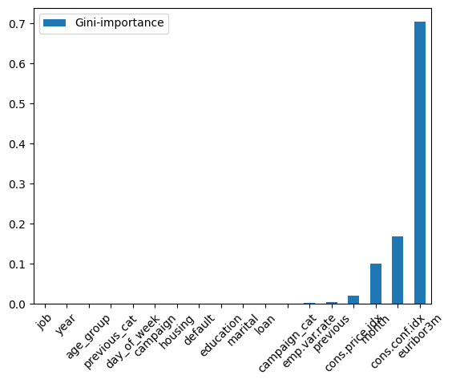

```python
# Vytvoření slovníku pro uchování feature_name a feature_importance
feats = {} # a dict to hold feature_name: feature_importance
for feature, importance in zip(feature_cols, model_tree.feature_importances_):
    feats[feature] = importance #add the name/value pair

# Měření významnosti jednotlivých proměnných (features) - Gini-importance
# Vytváří DataFrame pro důležitosti proměnných a vykresluje je jako sloupcový graf
importances = pd.DataFrame.from_dict(feats, orient='index').rename(columns={0: 'Gini-importance'})
importances.sort_values(by='Gini-importance').plot(kind='bar', rot=45)
```

```python
# Model rozhodovacího stromu s křížovou validací
# Definuje rozsah hyperparametrů pro hledání rozhodovací strom
param_dist = {"max_depth":(3,4,5,6,7,8,9,10),"min_samples_leaf":(1,2,3,4,5),
              "criterion": ["gini", "entropy"]}

# Ladění hyperparametrů pomocí GridSearchCV
model_tree_cv = GridSearchCV(model_tree, param_dist, cv=5)
model_tree_cv.fit(X_test,y_test)
```

```
GridSearchCV(cv=5, estimator=DecisionTreeClassifier(max_depth=3),
             param_grid={'criterion': ['gini', 'entropy'],
                         'max_depth': (3, 4, 5, 6, 7, 8, 9, 10),
                         'min_samples_leaf': (1, 2, 3, 4, 5)})
```

```python
# Trénování a predikce s nejlepším modelem, který jsme našly na základě kroku výše
model_tree_best = DecisionTreeClassifier( criterion='entropy', max_depth= 4, min_samples_leaf=4) # Nejlepší hyperparametry, které jsme našly pomocí GridSearchCV
model_tree_best.fit(X_train2,y_train2) #Trénování modelu na trénovacích datech
predictions_tree2 = model_tree_best.predict(X_test)
accuracy_score(y_test, predictions_tree2) # Vypočítání přesnosti modelu
```

[output not shown]

```
0.829084729303229
```

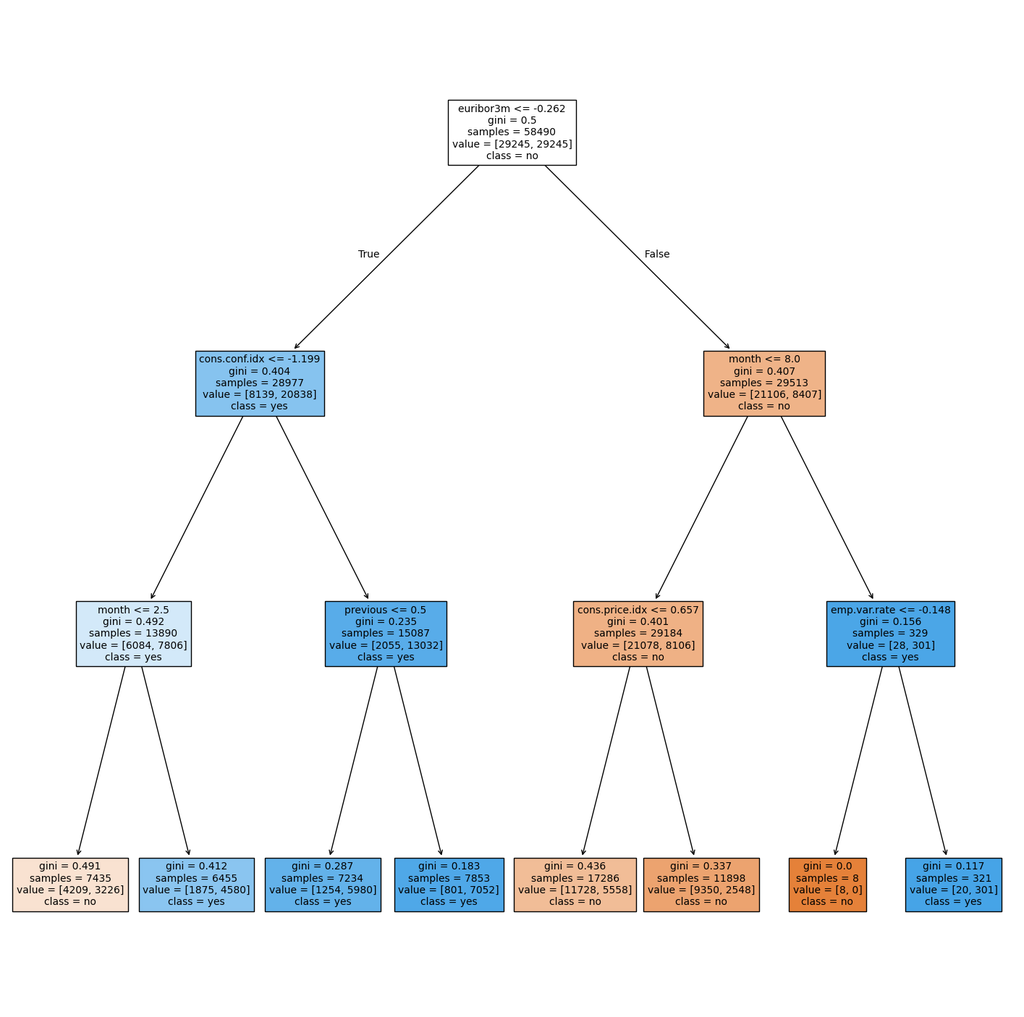

```python
# Manuálně nastavený rozhodovací strom a jeho vizualizace
plt.figure(figsize=(18,18))
plot_tree(model_tree,feature_names = list(X_train2.columns),
               class_names=["no","yes"],
            filled = True,fontsize=10)
matplotlib.pyplot.savefig('tree.png')
```

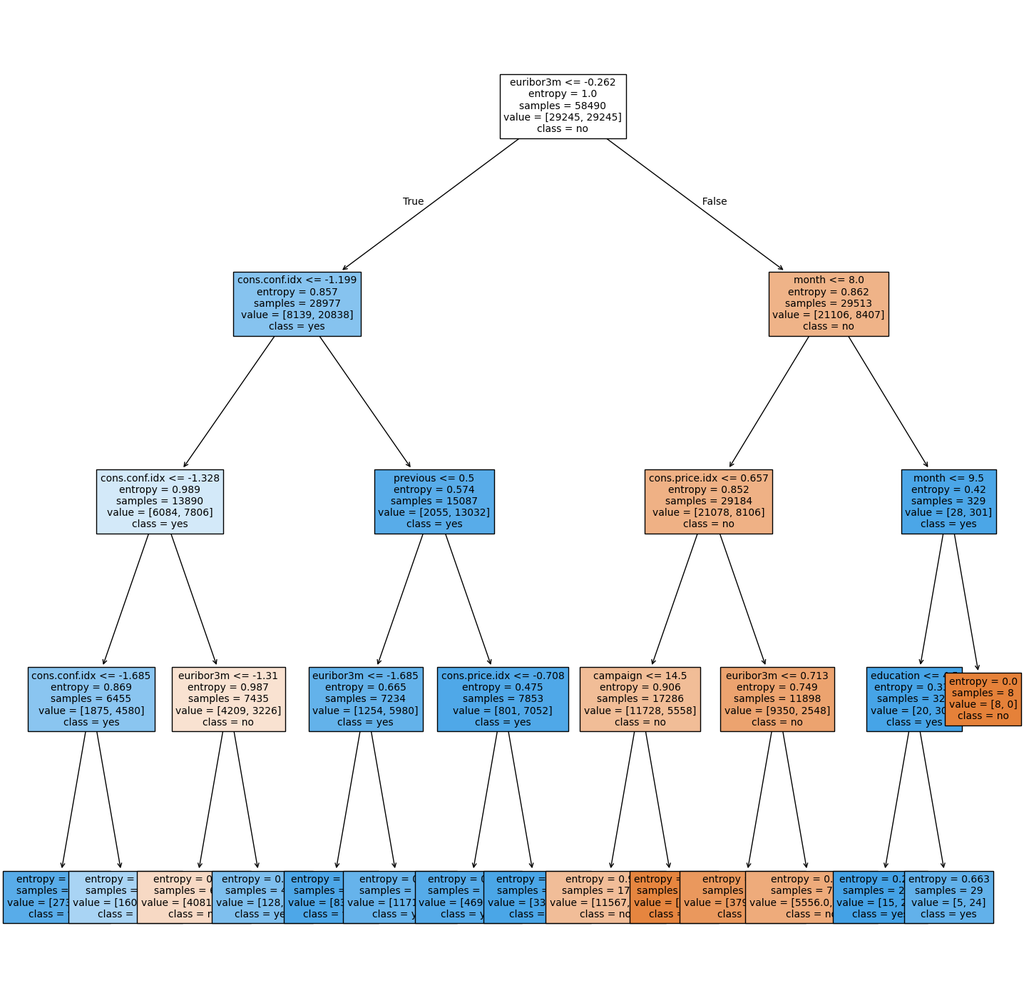

```python
# Vizualizace rozhodovacho stromu, který jsme získaly pomocí optimalizace s GridSearchCV
plt.figure(figsize=(18,18))
plot_tree(model_tree_best,feature_names = list(X_train2.columns),
               class_names=["no","yes"],
            filled = True,fontsize=10)
matplotlib.pyplot.savefig('tree2.png')
```

MODEL RANDOM FOREST

```python
# Vytvoření modelu náhodného lesa
model_forest = RandomForestClassifier(n_estimators=100, max_depth=5, random_state=42)
model_forest.fit(X_train2, y_train2) # Trénování modelu na trénovacích datech
predictions_forest = model_forest.predict(X_test) # Provedení predikce na základě testovacích dat
accuracy_score(y_test, predictions_forest) # Vypočítání přesnosti modelu
```

```
0.8292061179898034
```

```
[[6272 1031]
 [ 376  559]]
```

```
<sklearn.metrics._plot.confusion_matrix.ConfusionMatrixDisplay at 0x28b696150>
```

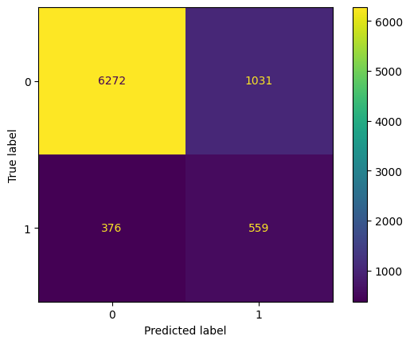

```python
# Vytvoření matice záměn pro hodnocení výkonu klasifikačního modelu
confmatrix=confusion_matrix(y_test, predictions_forest)
print(confmatrix)
ConfusionMatrixDisplay.from_estimator(model_forest, X_test, y_test)
```

Vyhodnocení matice záměn:

- TN (6.272): Počet případů, kdy model správně předpověděl třídu „ne“ (negativní) a skutečnost byla také „ne“.
- FP (1.031): Počet případů, kdy model nesprávně předpověděl třídu „ano“, ale skutečnost byla „ne“.
- FN (376): Počet případů, kdy model nesprávně předpověděl třídu „ne“, ale skutečnost byla „ano“.
- TP (559): Počet případů, kdy model správně předpověděl třídu „ano“ a skutečnost byla také „ano“.

```python
# Random forest  s křížovou validací
# Ladění nejlepších hyperparametrů pomocí GridSearchCV
parametergrid= {"criterion" : ("gini", "entropy"),"max_depth":(1,2,3,4,5),"min_samples_leaf":(1,2,3,4,5)
}
clf = GridSearchCV(RandomForestClassifier(random_state=42), parametergrid) # Provedení 5ti násobné křížové validace
clf.fit(X_train2, y_train2)
best_model=clf.best_estimator_ # Nejlepší model nalezený metodou GridSearchCV
best_params=clf.best_params_ # Nejlepší parametry tohoto modelu
best_score=clf.best_score_ # Nejlepší dosažené skóre

print("Nejlepší model:", best_model)
print("Nejlepší parametry:", best_params)
print("Nejlepší skóre:", best_score)
```

```
Nejlepší model: RandomForestClassifier(criterion='entropy', max_depth=5, min_samples_leaf=2,
                       random_state=42)
Nejlepší parametry: {'criterion': 'entropy', 'max_depth': 5, 'min_samples_leaf': 2}
Nejlepší skóre: 0.7431526756710548
```

```python
# Trénování a predikce s nejlepším modelem, který jsme našly na základě kroku výše
model_forest_best = RandomForestClassifier( criterion= 'entropy', max_depth= 5, min_samples_leaf=2)
model_forest_best.fit(X_train2,y_train2) # Trénování modelu na trénovacích datech
predictions_forest2 = model_forest.predict(X_test) # Provedení predikce na základě testovacích dat
accuracy_score(y_test, predictions_forest2) # Vypočátíní přesnosti modelu
```

```
0.8292061179898034
```

## VYHODNOCENÍ A POROVNÁNÍ MODELŮ

### Porovnání logistické regrese a logistické regrese s křížovou validací

```python
# Vyhodnocení modelu print("Logistická Regrese:")
print("Přesnost:", accuracy_score(y_test, y_pred_logreg)) # Vypočítá procento správných predikcí z celkového počtu -> přesnost modelu
print(classification_report(y_test, y_pred_logreg)) # Vypočítání metrik - precision, recall, f1-score, support
print("Koeficienty:", logreg.coef_)
print("Intercept:", logreg.intercept_)

# Vyhodnocení modelu print("Logistická RegreseCV:")
print("Přesnost:", accuracy_score(y_test, y_pred_log_cv)) # Vypočítá procento správných predikcí z celkového počtu
print(classification_report(y_test, y_pred_log_cv)) # Vypočítání metrik - precision, recall, f1-score, support
print("Koeficienty:", logreg_cv.coef_) # Výpis koeficientů
print("Intercept:", logreg_cv.intercept_) # Výpis intercept modelu - hodnota, kde model předpokládá, že výstup bude nula, když jsou všechny vstupní proměnné nulové
```

```
Přesnost: 0.7379218256858461
              precision    recall  f1-score   support

           0       0.95      0.74      0.83      7303
           1       0.26      0.69      0.37       935

    accuracy                           0.74      8238
   macro avg       0.60      0.72      0.60      8238
weighted avg       0.87      0.74      0.78      8238

Koeficienty: [[ 8.47974519e-03  3.87416767e-02 -1.34282735e-02 -1.64343408e-02
  -2.85652723e-03  2.13840723e-02  1.10147018e-01  2.18003896e-02
  -5.06847685e-02  6.04324455e-01 -7.16865745e-01  4.22044982e-01
   8.54494578e-02 -3.62996448e-01  1.52543157e-01 -2.52427963e-04
  -6.32137763e-01  2.99518601e-03]]
Intercept: [-0.00317565]
Přesnost: 0.7282107307598932
              precision    recall  f1-score   support

           0       0.95      0.73      0.83      7303
           1       0.25      0.70      0.37       935

    accuracy                           0.73      8238
   macro avg       0.60      0.72      0.60      8238
weighted avg       0.87      0.73      0.77      8238

Koeficienty: [[ 1.09719215e-02  3.64150482e-02 -1.21415629e-02 -2.56248888e-04
  -4.21438646e-04  2.10720304e-03  1.05043359e-01  1.20765412e-02
  -5.68770880e-02  1.16139078e-01 -2.70997784e-01  4.59578324e-02
   2.64484629e-02 -3.12539083e-01  1.22000711e-01 -5.04295544e-04
   6.48422871e-02  4.34359553e-03]]
Intercept: [-0.00065791]
```

### Výsledky logictické regrese

- Přesnost modelu (accuracy): 74 %.
- Precision pro třídu 0 (ne): 95 % (z klientů, které model klasifikoval jako „ne, neuzavřou vklad“, bylo 95 % skutečně správných). Za to přesnost pro třídu 1 byla pouze 26 %.
- Recall pro třídu 1 (ano): 69 % (model správně rozpoznal 69 % klientů, kteří uzavřeli vklad).
- F1-score: 0.83 pro třídu 0 a 0.37 pro třídu 1, což naznačuje, že model je velmi dobrý v klasifikaci třídy 0, ale slabší v klasifikaci třídy 1.

### Výsledky logictické regrese s křížovou validací

- Přesnost modelu (accuracy): 73 %.
- Precision pro třídu 0 (ne): 95 % (z klientů, které model klasifikoval jako „ne“, bylo 95 % skutečně správných).
- Recall pro třídu 1 (ano): 70 % (model správně rozpoznal 70 % klientů, kteří uzavřeli vklad).
- F1-score: 0.83 pro třídu 0 a 0.37 pro třídu 1, což naznačuje, že model je velmi dobrý v klasifikaci třídy 0, ale slabý v klasifikaci třídy 1.

### Shrnutí

Obě verze modelu vykazují podobné výsledky a dosahují celkové přesnosti 73-74 %. Mají velmi dobrou precision pro třídu 0 - 95 % - dobře předpovádají, že klient neuzavře termínovaný vklad. Recall (citlivost) je u obou modelů 73 - 74 %, což znamená, že modely zachytí skoro tři čtvrtiny všech případů této třídy 0. U třídy 1 jsou modely málo precizní a mají i vysokou míru falešných pozitiv. To znamená obtíže s predikcí klientů, kteří uzavřou vklad a naopak modely lépe klasifikují klienty, kteří vklad neuzavřou. Z hlediska výsledků jsou oba modely skoro totožné, v případě modelu bez křížové validace vychází některé ukazatele lépe jen o 1 %.

```python
# Porovnání logistické regrese a logistické regrese s křížovou validací
# Zobrazení intercept a koeficientů
print("Logistická Regrese:")
print("Intercept:", round(logreg.intercept_[0], 3))
for i, name in enumerate(feature_cols):
    print(name,": ",round(logreg.coef_[0,i],3))


print("Logistická RegreseCV:")
print("Intercept:", round(logreg_cv.intercept_[0], 3))
for i, name in enumerate(feature_cols):
    print(name,": ", round(logreg_cv.coef_[0,i],3))

print("\nIndividual fold scores: \n")
for i in range(5):
    print(i+1, ": ", round(logreg_cv.scores_[1][i][0], 5))

print ("The average score was: ", round(np.average(logreg_cv.scores_[1]),5))
```

```
Logistická Regrese:
Intercept: -0.003
job :  0.008
marital :  0.039
education :  -0.013
default :  -0.016
housing :  -0.003
loan :  0.021
month :  0.11
day_of_week :  0.022
campaign :  -0.051
previous :  0.604
emp.var.rate :  -0.717
cons.price.idx :  0.422
cons.conf.idx :  0.085
euribor3m :  -0.363
age_group :  0.153
year :  -0.0
previous_cat :  -0.632
campaign_cat :  0.003
Logistická RegreseCV:
Intercept: -0.001
job :  0.011
marital :  0.036
education :  -0.012
default :  -0.0
housing :  -0.0
loan :  0.002
month :  0.105
day_of_week :  0.012
campaign :  -0.057
previous :  0.116
emp.var.rate :  -0.271
cons.price.idx :  0.046
cons.conf.idx :  0.026
euribor3m :  -0.313
age_group :  0.122
year :  -0.001
previous_cat :  0.065
campaign_cat :  0.004

Individual fold scores:

1 :  0.72534
2 :  0.72508
3 :  0.72594
4 :  0.72294
5 :  0.72388
The average score was:  0.72464
```

```python
# Výpis klíčových metrik a matice záměn pro logistickou regresi
print("Logistic Model - manual")
print("Classification report: \n", classification_report(y_test, y_pred_logreg)) # Výpis klíčových metrik
# Vytvoření matice záměn
print("Confussion matrix")
mat  =confusion_matrix(y_test, y_pred_logreg)
conf_mat=pd.DataFrame({"True 0":[mat[0][0], mat[1][0]],
                 "True 1":[mat[0][1], mat[1][1]]})
conf_mat.index = ["Predicted 0", "Predicted 1"]
print(conf_mat, "\n")

# Výpis klíčových metrik a matice záměn pro logistickou regresi s křížovou validací
print("Logistic Model - cross validation")
print("Classification report: ")
print(classification_report(y_test, y_pred_log_cv))
print("Confussion matrix")
mat  =confusion_matrix(y_test, y_pred_log_cv)
conf_mat=pd.DataFrame({"True 0":[mat[0][0], mat[1][0]],
                 "True 1":[mat[0][1], mat[1][1]]})
conf_mat.index = ["Predicted 0", "Predicted 1"]
print(conf_mat)
```

```
Logistic Model - manual
Classification report:
               precision    recall  f1-score   support

           0       0.95      0.74      0.83      7303
           1       0.26      0.69      0.37       935

    accuracy                           0.74      8238
   macro avg       0.60      0.72      0.60      8238
weighted avg       0.87      0.74      0.78      8238

Confussion matrix
             True 0  True 1
Predicted 0    5432    1871
Predicted 1     288     647

Logistic Model - cross validation
Classification report:
              precision    recall  f1-score   support

           0       0.95      0.73      0.83      7303
           1       0.25      0.70      0.37       935

    accuracy                           0.73      8238
   macro avg       0.60      0.72      0.60      8238
weighted avg       0.87      0.73      0.77      8238

Confussion matrix
             True 0  True 1
Predicted 0    5345    1958
Predicted 1     281     654
```

[figure not shown]

```python
# ROC křivka
fpr, tpr, thresholds = roc_curve(y_true=y_test, y_score=y_prob_log)
fpr2, tpr2, thresholds2 = roc_curve(y_true=y_test, y_score=y_prob_log_cv)

# Vykreslení ROC křivky
plt.figure(figsize=(10, 6))
plt.plot([0, 1], [0, 1], 'k--', label='Náhodný klasifikátor')
plt.plot(fpr, tpr, label='Manuální hyperparametry')
plt.plot(fpr2, tpr2, label='Křížová validace (best params)')

# Nastavení grafu
plt.xlabel('Falešná pozitivní míra (FPR)')
plt.ylabel('Pravdivá pozitivní míra (TPR)')
plt.title('ROC křivka Random Forest Classifier')
plt.legend()
plt.grid()
plt.show()
```

Interpretace výsledků ROC křivky pro model logistické regrese

- **Modrá linie** - Představuje model logistické regrese, který byl nastaven s ručně laděnými hyperparametry. Vidíme, že jeho výkon je vyšší než náhodný klasifikátor, protože leží nad černou přerušovanou čarou.
- **Oranžová linie** - Představuje model logistické regrese s hyperparametry optimalizovanými křížovou validací. Oranžová linie je podobná modré, v průběhu místy mírně zaostává oproti modré linii, ale většinou je na podobné úrovni jako modrá linie.
- Oba modely jsou lepší než náhodný klasifikátor (černá přerušovaná čára). Jsou schopny lépe rozlišovat mezi pozitivními a negativními případy než náhodné tipování.
- Původní model logistické regrese si vede o trochu lépe, než laděný model křížovou validací. V tomto případě nevedla křížová validace ke zlepšení výkonu modelu.

### Porovnání rozhodovacího stromu a rozhodovacího stromu s křížovou validací

```python
print("Manuálně nastavený decisiontree \n")
print(classification_report(y_test, predictions_tree))  # Vypočítání metrik - precision, recall, f1-score, support
print(accuracy_score(y_test, predictions_tree), "\n") # Vypočítá procento správných predikcí z celkového počtu
# confusion_matrix - Zobrazuje počet skutečných pozitivních a negativních případů v porovnání s predikcemi.
mat  =confusion_matrix(y_test, predictions_tree)
conf_mat=pd.DataFrame({"True 0":[mat[0][0], mat[1][0]],
                 "True 1":[mat[0][1], mat[1][1]]})
conf_mat.index = ["Predicted 0", "Predicted 1"]
print(conf_mat, "\n")

print("Decision tree pomocí GridSearchCV \n")
print(classification_report(y_test, predictions_tree2))  # Vypočítání metrik - precision, recall, f1-score, support
print(accuracy_score(y_test, predictions_tree2),"\n") # Vypočítá procento správných predikcí z celkového počtu
# confusion_matrix - Zobrazuje počet skutečných pozitivních a negativních případů v porovnání s predikcemi.
mat  =confusion_matrix(y_test, predictions_tree2)
conf_mat=pd.DataFrame({"True 0":[mat[0][0], mat[1][0]],
                 "True 1":[mat[0][1], mat[1][1]]})
conf_mat.index = ["Predicted 0", "Predicted 1"]
print(conf_mat, "\n")
```

```
Manuálně nastavený decisiontree

              precision    recall  f1-score   support

           0       0.94      0.86      0.90      7303
           1       0.35      0.59      0.44       935

    accuracy                           0.83      8238
   macro avg       0.65      0.72      0.67      8238
weighted avg       0.88      0.83      0.85      8238

0.8312697256615683

             True 0  True 1
Predicted 0    6301    1002
Predicted 1     388     547

Decision tree pomocí GridSearchCV

              precision    recall  f1-score   support

           0       0.94      0.86      0.90      7303
           1       0.35      0.60      0.44       935

    accuracy                           0.83      8238
   macro avg       0.65      0.73      0.67      8238
weighted avg       0.88      0.83      0.85      8238

0.829084729303229

             True 0  True 1
Predicted 0    6271    1032
Predicted 1     376     559
```

### Výsledky manuálně nastaveného Decision Tree:

- Přesnost (accuracy): 83,10 %.
- Precision pro třídu 0 (ne): 94 % (z klientů, které model klasifikoval jako „ne“, bylo 94 % skutečně správných).
- Recall pro třídu 1 (ano): 59 % (model správně rozpoznal 59 % klientů, kteří uzavřeli vklad s 35% precision).
- F1-score: 0.90 pro třídu 0 a 0.44 pro třídu 1. Model dobře klasifikuje třídu 0, ale má slabší výkon pro třídu 1.

Matice záměn:

- Model správně klasifikoval 6301 případů třídy 0 a 547 případů třídy 1.
- Model chybně klasifikoval 1002 negativních případů jako pozitivní a 388 pozitivních případů jako negativní.

### Výsledky modelu vyladěného pomocí GridSearchCV:

- Přesnost (accuracy): 82,9 % (velmi podobná manuálně nastavenému modelu).
- Precision, recall a F1-score jsou stejné jako u manuálně nastaveného modelu. Liší se pouze recall pro 1. třídu o 1 %.

Matice záměn:

- Model správně klasifikoval 6271 případů třídy 0 a 559 případů třídy 1.
- Chybně klasifikoval 1032 negativních případů jako pozitivní a 376 pozitivních případů jako negativní.

### Porovnání manuálně nastaveného Random Forest modelu a modelu, který byl vyladěn pomocí GridSearchCV

```python
# Porovnání manuálně nastaveného Random Forest modelu a modelu, který byl vyladěn pomocí GridSearchCV
print("Manuálně nastavený Random forest\n")
print(classification_report(y_test, predictions_forest)) # Vypočítání metrik - precision, recall, f1-score, support
print(accuracy_score(y_test, predictions_forest),"\n") # Vypočítá procento správných predikcí z celkového počtu
# confusion_matrix - Zobrazuje počet skutečných pozitivních a negativních případů v porovnání s predikcemi.
mat  =confusion_matrix(y_test, predictions_forest)
conf_mat=pd.DataFrame({"True 0":[mat[0][0], mat[1][0]],
                 "True 1":[mat[0][1], mat[1][1]]})
conf_mat.index = ["Predicted 0", "Predicted 1"]
print(conf_mat, "\n")

print(" Random forest pomocí GridSearchCV \n")
print(classification_report(y_test, predictions_forest2)) # Vypočítání metrik - precision, recall, f1-score, support
print(accuracy_score(y_test, predictions_forest2),"\n") # Vypočítá procento správných predikcí z celkového počtu
# confusion_matrix - Zobrazuje počet skutečných pozitivních a negativních případů v porovnání s predikcemi.
mat  =confusion_matrix(y_test, predictions_forest2)
conf_mat=pd.DataFrame({"True 0":[mat[0][0], mat[1][0]],
                 "True 1":[mat[0][1], mat[1][1]]})
conf_mat.index = ["Predicted 0", "Predicted 1"]
print(conf_mat, "\n")
```

```
Manuálně nastavený Random forest

              precision    recall  f1-score   support

           0       0.94      0.86      0.90      7303
           1       0.35      0.60      0.44       935

    accuracy                           0.83      8238
   macro avg       0.65      0.73      0.67      8238
weighted avg       0.88      0.83      0.85      8238

0.8292061179898034

             True 0  True 1
Predicted 0    6272    1031
Predicted 1     376     559

 Random forest pomocí GridSearchCV

              precision    recall  f1-score   support

           0       0.94      0.86      0.90      7303
           1       0.35      0.60      0.44       935

    accuracy                           0.83      8238
   macro avg       0.65      0.73      0.67      8238
weighted avg       0.88      0.83      0.85      8238

0.8292061179898034

             True 0  True 1
Predicted 0    6272    1031
Predicted 1     376     559
```

### Výsledky manuálně nastaveného modelu Random forest :

- Přesnost (accuracy): 82,9 %.
- Precision pro třídu 0 (ne): 94 % (z klientů, které model klasifikoval jako „ne“, bylo 94 % skutečně správných).
- Recall pro třídu 1 (ano): 60 % (model správně rozpoznal 60 % klientů, kteří uzavřeli vklad s 35% precision).
- F1-score: 0.90 pro třídu 0 a 0.44 pro třídu 1 znamená, že model je velmi dobrý v klasifikaci třídy 0, ale slabší v klasifikaci třídy 1.

Matice záměn:

- Model správně předpověděl 6272 negativních případů a 559 pozitivních případů.
- Chybně klasifikoval 1031 negativních případů jako pozitivní a 376 pozitivních případů jako negativní.

### Závěr:

Všechny modely excelují v klasifikaci třídy 0 (neuzavření vkladu), ale mají problémy s predikcí třídy 1 (uzavření vkladu). Křížová validace zlepšuje schopnost modelů generalizovat na nových datech, ale v některých případech (např. u náhodného lesa a rozhodovacího stromu) nepřináší žádné zlepšení výkonnosti. Ladění hyperparametrů pomocí GridSearchCV nemělo v žádném případě zásadní vliv na zlepšení výsledků oproti manuálně nastaveným modelům. Pro zlepšení výsledků by bylo vhodné přistoupit k pokročilým metodám jako jsou gradient boosting modely nebo modely optimalizovat více na recall pro třídu 1.